# Analyses of bacterial diversity

### Zamia Coralloid root Cyanobacteria community

### Contributors

Juan Carlos Villarreal A.

Adriel M. Sierra

To study the coralloid root cyanobacteria community of two Zamia species, we used the processed *phyloseq* object with the whole bacterial community identified using the 16S marker. From this dataset, we subset all ASVs whose phylum corresponds to Cyanobacteria.

First we use a subset dataset with only ASVs whose phylum corresponds to Cyanobacteria in the 16S dataset.

```r
knitr::opts_knit$set(root.dir = "/Users/adrielsierra/Documents/GitHub/cycads_rbcLX_roots")
root16ps = readRDS("./Data/Zamia_root_bacteria16s_ps_mai23.rds")
ps_cyano = subset_taxa(root16ps, Phylum=="Cyanobacteria")
ps_cyano
```

```
## phyloseq-class experiment-level object
## otu_table()   OTU Table:         [ 101 taxa and 53 samples ]
## sample_data() Sample Data:       [ 53 samples by 5 sample variables ]
## tax_table()   Taxonomy Table:    [ 101 taxa by 7 taxonomic ranks ]
## phy_tree()    Phylogenetic Tree: [ 101 tips and 100 internal nodes ]
```

Second, we use the cyanobacterial community identified with the amplicon marker rbcL-X.

```r
knitr::opts_knit$set(root.dir = "/Users/adrielsierra/Documents/GitHub/cycads_rbcLX_roots")
rbclx.ps = readRDS("./Data/RBCLX_ps_rootZamia.rds")
rbclx.ps
```

```
## phyloseq-class experiment-level object
## otu_table()   OTU Table:         [ 175 taxa and 25 samples ]
## sample_data() Sample Data:       [ 25 samples by 3 sample variables ]
## tax_table()   Taxonomy Table:    [ 175 taxa by 6 taxonomic ranks ]
```

Analyses of Cyanobacterial diversity using the 16S and rbcL-X markers

### Compute and visualize alpha diversity

To the data frame we add an extra column with read count by sample, the Zamia host species, and locality respective to each sample.

```r
richness.df.cyano = estimate_richness(ps_cyano, split = TRUE, measures = c("Observed","Shannon", "Simpson"))
richness.df.cyano$Pielou = richness.df.cyano$Shannon/log(specnumber(otu_table(ps_cyano)))
richness.df.cyano$readcount = sample_sums(ps_cyano)
richness.df.cyano$Host = as.factor(ps_cyano@sam_data$Species)
richness.df.cyano$Locality = as.factor(ps_cyano@sam_data$Locality)
```

```r
richness.rbclx.df = estimate_richness(rbclx.ps, split = TRUE, measures = c("Observed","Shannon", "Simpson"))
richness.rbclx.df$Pielou = richness.rbclx.df$Shannon/log(specnumber(t(otu_table(rbclx.ps))))
richness.rbclx.df$readcount = sample_sums(rbclx.ps)
richness.rbclx.df$Host = as.factor(rbclx.ps@sam_data$Species_name)
richness.rbclx.df$Locality = as.factor(rbclx.ps@sam_data$Site)
```

### Alpha diversity table : Richness indexes estimates of the cyanobacteria community identified with the 16S marker in coralloid roots of the two species *Z. nana* and *Z. pseudoparasitica*.

```r
DT::datatable(richness.df.cyano) %>%
    formatRound(columns=c('Shannon', 'Simpson', 'Pielou'), digits=4)
```

|  | Observed | Shannon | Simpson | Pielou | readcount | Host | Locality |
| --- | --- | --- | --- | --- | --- | --- | --- |
| X10S | 6 | 1.23151616046822 | 0.645939221043004 | 0.687322255926904 | 2999 | Zamia pseudoparasitica | Donoso |
| X11S | 8 | 1.62870065785748 | 0.764602531464018 | 0.783239454061191 | 167 | Zamia nana | El Valle, Cerro Gaital |
| X12S | 6 | 1.20551777217355 | 0.641384845598984 | 0.672812279146443 | 3269 | Zamia pseudoparasitica | Donoso |
| X13S | 5 | 1.24525964504716 | 0.656908584075497 | 0.7737233200651 | 2443 | Zamia pseudoparasitica | Donoso |
| X14S | 9 | 1.29082594328878 | 0.651997561338661 | 0.58748020416452 | 4579 | Zamia pseudoparasitica | Donoso |
| X15S | 11 | 1.29742206113786 | 0.640520518406902 | 0.541067024842895 | 5137 | Zamia pseudoparasitica | Donoso |
| X16S | 5 | 1.23824383328713 | 0.649900357607682 | 0.769364151124303 | 2299 | Zamia pseudoparasitica | Donoso |
| X17S | 4 | 1.05875835050612 | 0.599915487201957 | 0.763732710887482 | 3445 | Zamia nana | El Valle, Cerro Gaital |
| X18S | 7 | 1.26625081514199 | 0.661275472266613 | 0.650724194925814 | 2249 | Zamia nana | El Valle, Cerro Gaital |
| X19S | 4 | 1.32711964607567 | 0.721738271604938 | 0.957314466029841 | 225 | Zamia nana | El Valle, Cerro Gaital |

[output cut: 43 more lines]

### Alpha diversity table : Richness indexes estimates of the cyanobacteria community identified with the rbcL-X marker in coralloid roots of the two species *Z. nana* and *Z. pseudoparasitica*.

```r
DT::datatable(richness.rbclx.df)%>%
    formatRound(columns=c('Shannon', 'Simpson', 'Pielou'), digits=4)
```

|  | Observed | Shannon | Simpson | Pielou | readcount | Host | Locality |
| --- | --- | --- | --- | --- | --- | --- | --- |
| Zn.1R | 4 | 0.891441786532632 | 0.549273833659806 | 0.643039322335913 | 71514 | Zamia nana | Gaital |
| Zn.25R | 33 | 1.47159416005061 | 0.714167365734258 | 0.420875440473352 | 79551 | Zamia nana | Gaital |
| Zn.26R | 26 | 1.55955007031733 | 0.706479952376432 | 0.478669079358952 | 38287 | Zamia nana | Gaital |
| Zn.27R | 33 | 1.16509253071246 | 0.616548825389151 | 0.333216076393613 | 105238 | Zamia nana | Gaital |
| Zn.28R | 14 | 0.299346842431142 | 0.109116314993521 | 0.113429457962849 | 104016 | Zamia nana | Gaital |
| Zn.3R | 4 | 0.0145280699749611 | 0.0034899516841157 | 0.0104797872532821 | 85283 | Zamia nana | Gaital |
| Zn.4R | 4 | 0.00489491124997962 | 0.0010432912115812 | 0.00353093209296859 | 93896 | Zamia nana | Gaital |
| Zn.5R | 4 | 0.0294248000856802 | 0.00767308278726386 | 0.02122550658138 | 93853 | Zamia nana | Gaital |
| Zn.6R | 5 | 0.399060246470943 | 0.175467631947463 | 0.247950072126366 | 73607 | Zamia nana | Gaital |
| Zn.7R | 5 | 1.1956296032135 | 0.68312418510185 | 0.742886441270195 | 89205 | Zamia nana | Gaital |

[output cut: 15 more lines]

### Correlation of richness with read count

Here, we evaluated if sequencing depth bias toward over or underestimation of cyanobacterial community diversity by correlating the observed species richness and the read count by sample (coverage) with the Kendall method.

**16S**

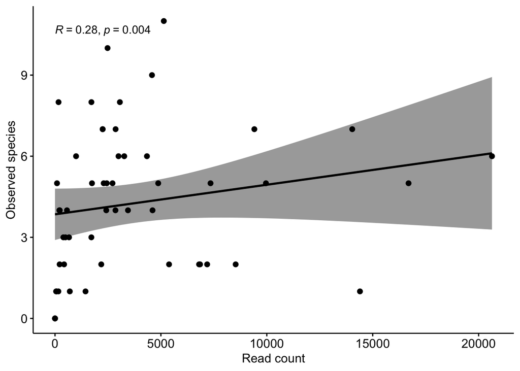

```r
cor.16s.cyano = ggscatter(richness.df.cyano, x = "readcount", y = "Observed",
          add = "reg.line", conf.int = TRUE,
          cor.coef = TRUE, cor.method = "kendall",
          xlab = "Read count", ylab = "Observed species")
cor.16s.cyano
```

**rbcL-X**

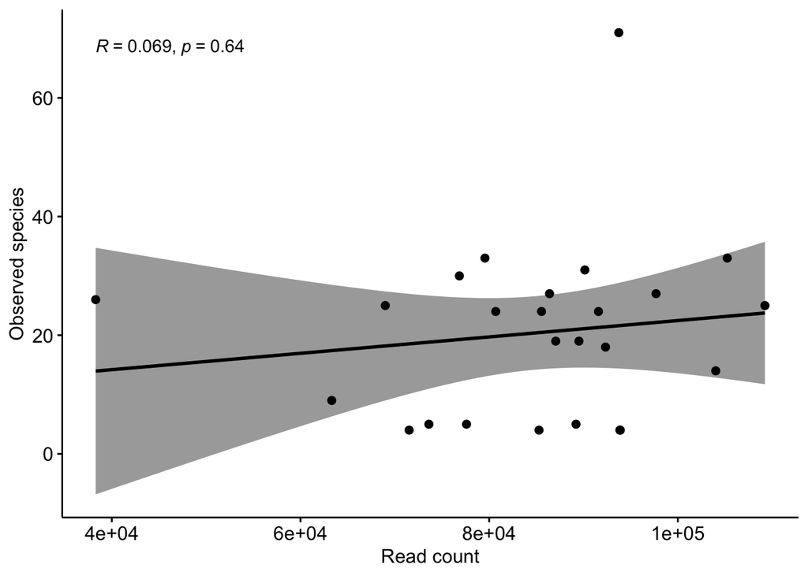

```r
cor.rbclx = ggscatter(richness.rbclx.df, x = "readcount", y = "Observed",
          add = "reg.line", conf.int = TRUE,
          cor.coef = TRUE, cor.method = "kendall",
          xlab = "Read count", ylab = "Observed species")
cor.rbclx
```

### Rarefaction curves

For the two Zamia species separately, species accumulation curves (100 permutations) were generated from sample-based rarefactions using the Coleman method (Coleman et al. 1982) with the function specaccum in the vegan package (Oksanen et al. 2016).

**16S**

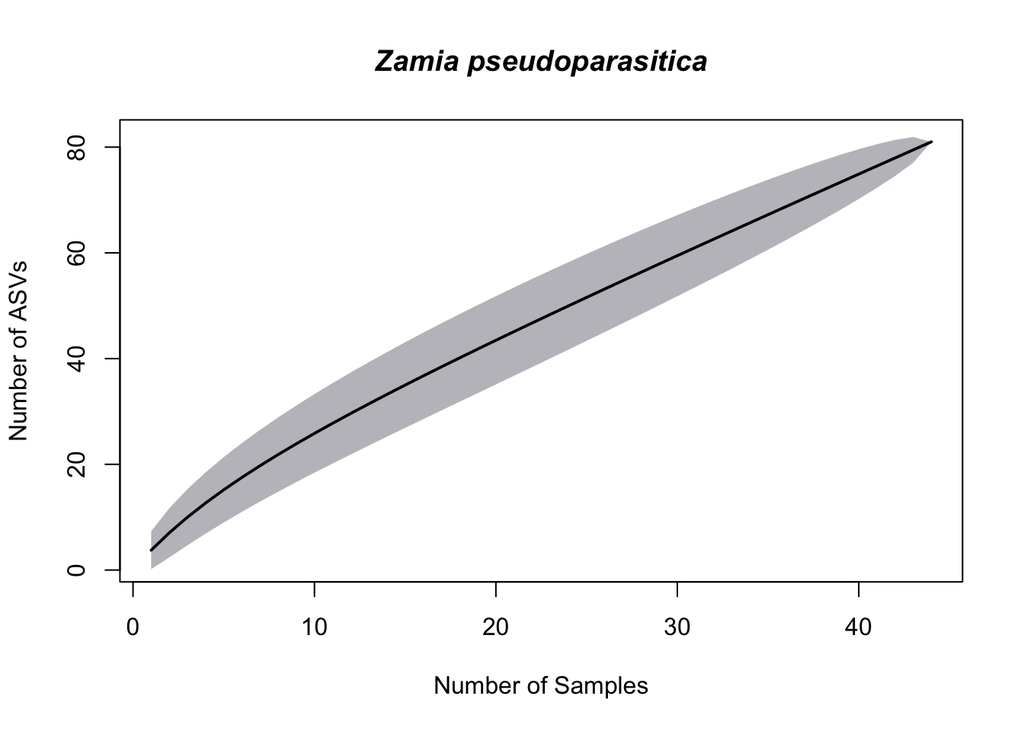

```r
cyano.zpseudo <- subset_samples(ps_cyano, Species %in% c("Zamia pseudoparasitica"))
cyano.znana <- subset_samples(ps_cyano, Species %in% c("Zamia nana"))

rarezpseudo.cyano<-specaccum(otu_table(cyano.zpseudo), method = "coleman", permutations = 100, conditioned =TRUE, gamma = "coleman")
plot(rarezpseudo.cyano, main="Zamia pseudoparasitica", font.main= 4, add = F, ci = 2, ci.type = "polygon", col = "black",  lwd=1.9, ci.lty=0, ci.col = rgb(blue=0.1, green=0, red=0, alpha =0.3), xlab = "Number of Samples", ylab="Number of ASVs")
```

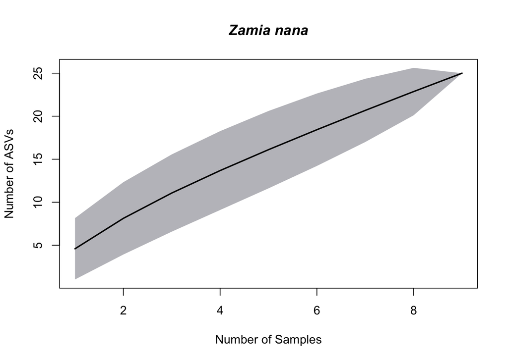

```r
rareznana.cyano<-specaccum(otu_table(cyano.znana), method = "coleman", permutations = 100, conditioned =TRUE, gamma = "coleman")
plot(rareznana.cyano, main= "Zamia nana", font.main= 4, add = F, ci = 2, ci.type = "polygon", col = "black",  lwd=1.9, ci.lty=0, ci.col = rgb(blue=0.1, green=0, red=0, alpha =0.3), xlab = "Number of Samples", ylab="Number of ASVs")
```

**rbcL-X**

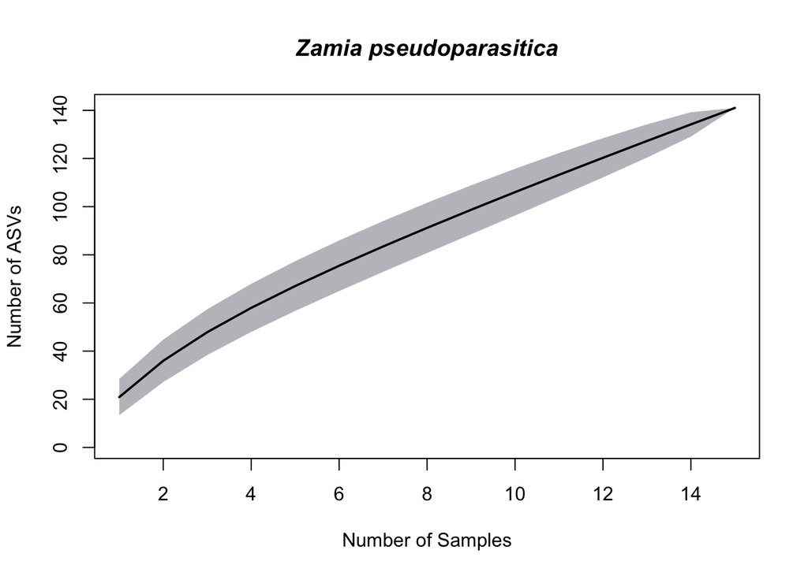

```r
ps_pseudo <- subset_samples(rbclx.ps, Species_name %in% c("Zamia pseudoparasitica"))
ps_nana <- subset_samples(rbclx.ps, Species_name %in% c("Zamia nana"))

rarezpseudo.rbclx <-specaccum(t(otu_table(ps_pseudo)), method = "coleman", permutations = 100, conditioned =TRUE, gamma = "coleman")
plot(rarezpseudo.rbclx, main="Zamia pseudoparasitica", font.main= 4, add = F, ci = 2, ci.type = "polygon", col = "black",  lwd=1.9, ci.lty=0, ci.col = rgb(blue=0.1, green=0, red=0, alpha =0.3), xlab = "Number of Samples", ylab="Number of ASVs")
```

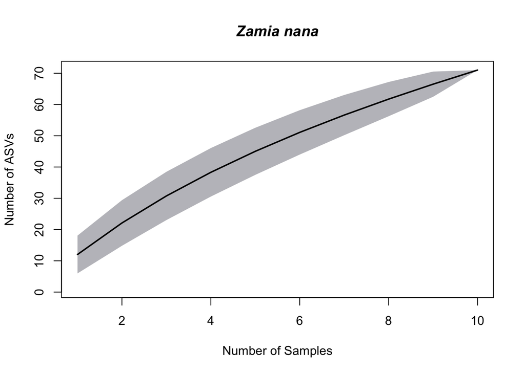

```r
rareznana.rbclx <-specaccum(t(otu_table(ps_nana)), method = "coleman", permutations = 100, conditioned =TRUE, gamma = "coleman")
plot(rareznana.rbclx, main= "Zamia nana", font.main= 4, add = F, ci = 2, ci.type = "polygon", col = "black",  lwd=1.9, ci.lty=0, ci.col = rgb(blue=0.1, green=0, red=0, alpha =0.3), xlab = "Number of Samples", ylab="Number of ASVs")
```

### Extrapolate species richness

Estimated species richness was also extrapolated for each species with three non-parametric methods. The Chao Index with standard error (Chao 1987) was estimated using the small sampling corrections to reduce estimation bias by multiplying (N-1)/N to the basic Chao equation (Gotelli & Colwell 2001) as implemented by the function specpool in the vegan R package. First-order Jackknife estimators and the Bootstrap estimator with standard error were also used, as it is considered a more accurate measure of species richness from datasets with a high number of singletons and doubletons. Pearson’s Chi-squared Test was used to test for significant differences between the observed species and extrapolated richness with the three non-parametric methods.

**16S**

```r
pool16s = specpool(ps_cyano@otu_table, ps_cyano@sam_data$Species, smallsample = TRUE)

DT::datatable(pool16s)%>%
    formatRound(colnames(pool16s),digits=2)
```

|  | Species | chao | chao.se | jack1 | jack1.se | jack2 | boot | boot.se | n |
| --- | --- | --- | --- | --- | --- | --- | --- | --- | --- |
| Zamia nana | 25 | 105.222222222222 | 68.2120875570371 | 41.8888888888889 | 8.78831997034897 | 55.3055555555556 | 31.7957136541635 | 4.06788465475545 | 9 |
| Zamia pseudoparasitica | 81 | 2274.48863636364 | 2258.50242280753 | 146.477272727273 | 14.170650468865 | 209.499471458774 | 105.654014454995 | 5.99717976754863 | 44 |

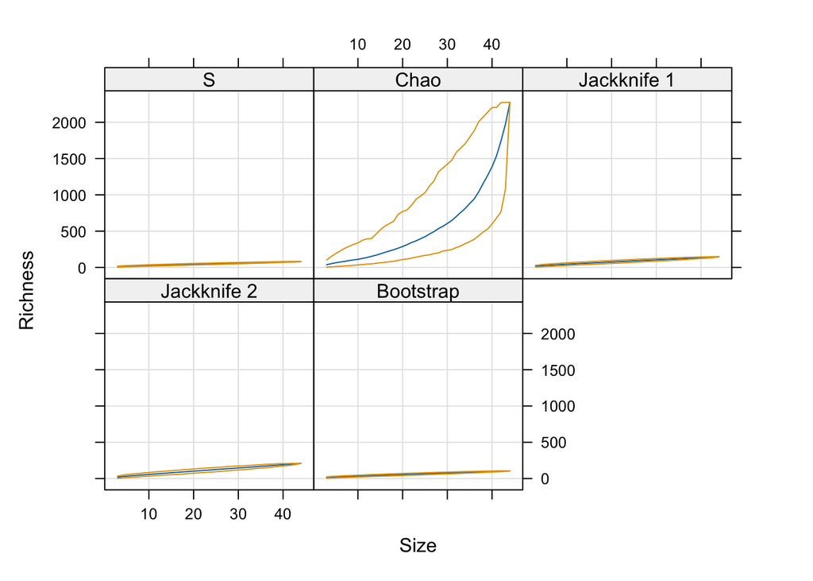

```r
cyano_pseudo_acc = poolaccum(cyano.zpseudo@otu_table, permutations = 999)
plot(cyano_pseudo_acc)
```

```r
chisq.test(cyano_pseudo_acc$chao, cyano_pseudo_acc$S, correct = TRUE)
```

```
##
##  Pearson's Chi-squared test
##
## data:  cyano_pseudo_acc$chao
## X-squared = 3520539, df = 40918, p-value < 2.2e-16
```

```r
chisq.test(cyano_pseudo_acc$jack1, cyano_pseudo_acc$S, correct = TRUE)
```

```
##
##  Pearson's Chi-squared test
##
## data:  cyano_pseudo_acc$jack1
## X-squared = 32056, df = 40918, p-value = 1
```

```r
chisq.test(cyano_pseudo_acc$boot, cyano_pseudo_acc$S, correct = TRUE)
```

```
##
##  Pearson's Chi-squared test
##
## data:  cyano_pseudo_acc$boot
## X-squared = 21949, df = 40918, p-value = 1
```

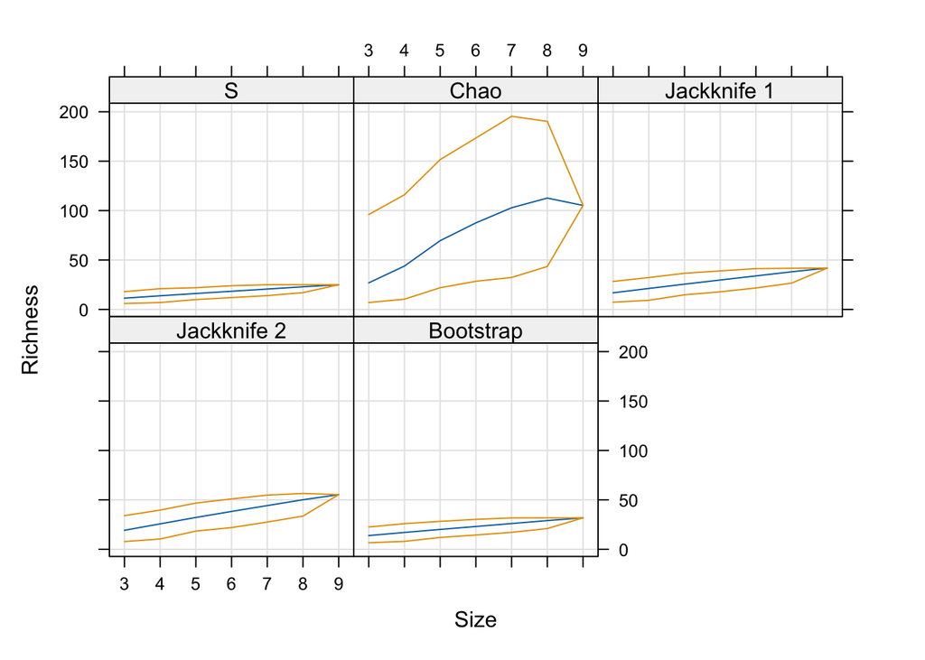

```r
cyano_nana_acc = poolaccum(cyano.znana@otu_table, permutations = 999)
plot(cyano_nana_acc)
```

```r
chisq.test(cyano_nana_acc$chao, cyano_nana_acc$S,correct = TRUE)
```

```
##
##  Pearson's Chi-squared test
##
## data:  cyano_nana_acc$chao
## X-squared = 67354, df = 5988, p-value < 2.2e-16
```

```r
chisq.test(cyano_nana_acc$jack1, cyano_nana_acc$S, correct = TRUE)
```

```
##
##  Pearson's Chi-squared test
##
## data:  cyano_nana_acc$jack1
## X-squared = 5034.7, df = 5988, p-value = 1
```

```r
chisq.test(cyano_nana_acc$boot, cyano_nana_acc$S, correct = TRUE)
```

```
##
##  Pearson's Chi-squared test
##
## data:  cyano_nana_acc$boot
## X-squared = 3425.3, df = 5988, p-value = 1
```

**rbcL-X**

```r
poolrbclx = specpool(t(rbclx.ps@otu_table), rbclx.ps@sam_data$Species_name, smallsample = TRUE)

DT::datatable(poolrbclx)%>%
    formatRound(colnames(poolrbclx), digits=2)
```

|  | Species | chao | chao.se | jack1 | jack1.se | jack2 | boot | boot.se | n |
| --- | --- | --- | --- | --- | --- | --- | --- | --- | --- |
| Zamia nana | 71 | 158.12 | 39.1931095984996 | 110.6 | 20.3823453017556 | 138.688888888889 | 87.7130973674 | 10.837785770461 | 10 |
| Zamia pseudoparasitica | 141 | 950.2 | 368.268814862187 | 236.2 | 56.8534959347268 | 319.771428571429 | 178.225902611439 | 27.4206735336516 | 15 |

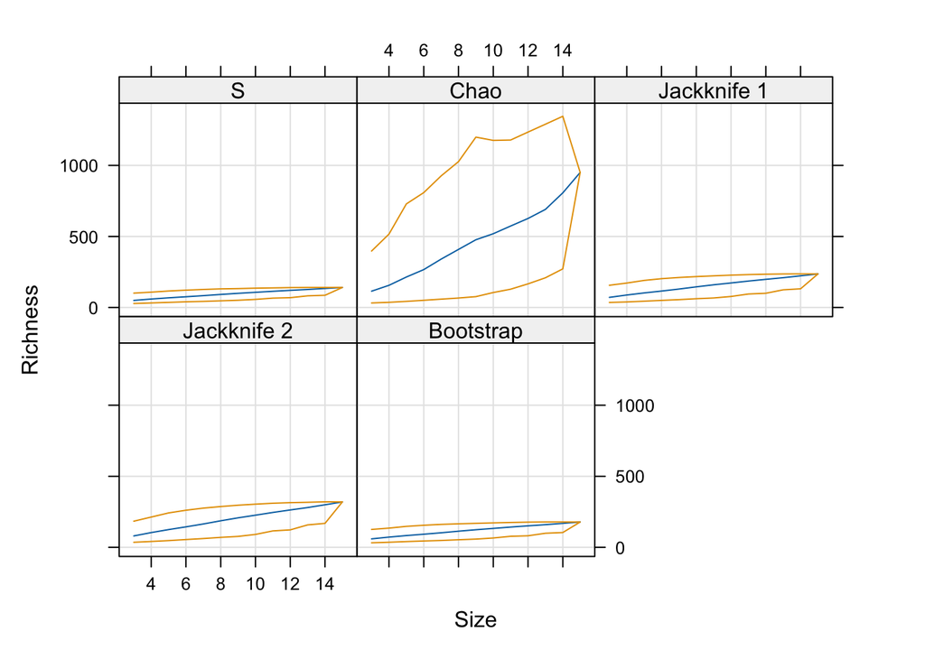

```r
ps_pseudo_acc = poolaccum(t(ps_pseudo@otu_table), permutations = 999)
plot(ps_pseudo_acc)
```

```r
chisq.test(ps_pseudo_acc$chao, ps_pseudo_acc$S,correct = TRUE)
```

```
##
##  Pearson's Chi-squared test
##
## data:  ps_pseudo_acc$chao
## X-squared = 1080267, df = 11976, p-value < 2.2e-16
```

```r
chisq.test(ps_pseudo_acc$jack1, ps_pseudo_acc$S, correct = TRUE)
```

```
##
##  Pearson's Chi-squared test
##
## data:  ps_pseudo_acc$jack1
## X-squared = 100555, df = 11976, p-value < 2.2e-16
```

```r
chisq.test(ps_pseudo_acc$boot, ps_pseudo_acc$S, correct = TRUE)
```

```
##
##  Pearson's Chi-squared test
##
## data:  ps_pseudo_acc$boot
## X-squared = 66573, df = 11976, p-value < 2.2e-16
```

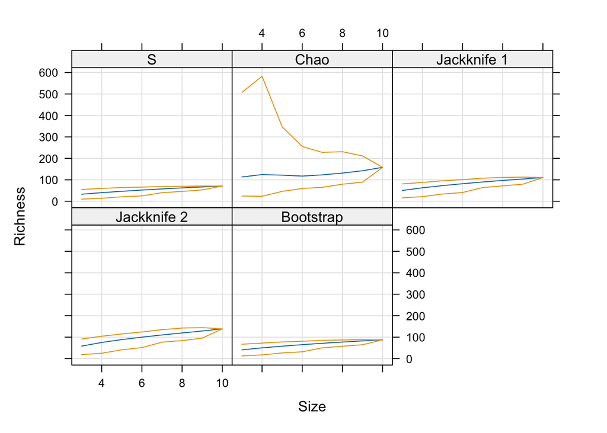

```r
ps_nana_acc = poolaccum(t(ps_nana@otu_table), permutations = 999)
plot(ps_nana_acc)
```

```r
chisq.test(ps_nana_acc$chao, ps_nana_acc$S, correct = TRUE)
```

```
##
##  Pearson's Chi-squared test
##
## data:  ps_nana_acc$chao
## X-squared = 154504, df = 6986, p-value < 2.2e-16
```

```r
chisq.test(ps_nana_acc$jack1, ps_nana_acc$S,  correct = TRUE)
```

```
##
##  Pearson's Chi-squared test
##
## data:  ps_nana_acc$jack1
## X-squared = 14732, df = 6986, p-value < 2.2e-16
```

```r
chisq.test(ps_nana_acc$boot, ps_nana_acc$S, correct = TRUE)
```

```
##
##  Pearson's Chi-squared test
##
## data:  ps_nana_acc$boot
## X-squared = 11990, df = 6986, p-value < 2.2e-16
```

### Complete richness dataframe with the two markers

First we joined in a single the two dataframes with richness estimates with the 16S marker and rbcL-X marker.

```r
cyano.div.com = data.frame(rbind(richness.df.cyano, richness.rbclx.df))
cyano.div.com$Marker = as.factor(c(rep("16S",53), rep("rbcL-X",25)))
```

The assumptions of normality was tested with the Shapiro-Wilk Test for the richness estimates from the dataset generated with the rbcL-X marker

```r
shapiro.test(richness.rbclx.df$Observed)
```

```
##
##  Shapiro-Wilk normality test
##
## data:  richness.rbclx.df$Observed
## W = 0.82983, p-value = 0.0007467
```

```r
shapiro.test(richness.rbclx.df$Shannon)
```

```
##
##  Shapiro-Wilk normality test
##
## data:  richness.rbclx.df$Shannon
## W = 0.89509, p-value = 0.01436
```

```r
shapiro.test(richness.rbclx.df$Simpson)
```

```
##
##  Shapiro-Wilk normality test
##
## data:  richness.rbclx.df$Simpson
## W = 0.81165, p-value = 0.0003579
```

```r
shapiro.test(richness.rbclx.df$Pielou)
```

```
##
##  Shapiro-Wilk normality test
##
## data:  richness.rbclx.df$Pielou
## W = 0.90601, p-value = 0.02485
```

The homogeneity of variance were tested with the Levene test

```r
test_names <- c( "Observed", "Shannon", "Simpson", "Pielou")
for (test in test_names) {
  test_formula <- paste(test,"~","Marker")
  print(paste("Testing homogeneity of variance:", test))
  print(leveneTest(as.formula(test_formula), data=cyano.div.com))
}
```

```
## [1] "Testing homogeneity of variance: Observed"
## Levene's Test for Homogeneity of Variance (center = median)
##       Df F value    Pr(>F)
## group  1  32.433 2.212e-07 ***
##       76
## ---
## Signif. codes:  0 '***' 0.001 '**' 0.01 '*' 0.05 '.' 0.1 ' ' 1
## [1] "Testing homogeneity of variance: Shannon"
## Levene's Test for Homogeneity of Variance (center = median)
##       Df F value  Pr(>F)
## group  1  5.4782 0.02188 *
##       76
## ---
## Signif. codes:  0 '***' 0.001 '**' 0.01 '*' 0.05 '.' 0.1 ' ' 1
## [1] "Testing homogeneity of variance: Simpson"
## Levene's Test for Homogeneity of Variance (center = median)
##       Df F value   Pr(>F)
## group  1   6.988 0.009962 **
##       76
## ---
## Signif. codes:  0 '***' 0.001 '**' 0.01 '*' 0.05 '.' 0.1 ' ' 1
## [1] "Testing homogeneity of variance: Pielou"
## Levene's Test for Homogeneity of Variance (center = median)
##       Df F value    Pr(>F)
## group  1  17.354 8.723e-05 ***
##       70
## ---
## Signif. codes:  0 '***' 0.001 '**' 0.01 '*' 0.05 '.' 0.1 ' ' 1
```

Here, the significant differences between species and markers were assessed by fitting an Analysis of Variance Model (ANOVA). Two-way ANOVA model use *Zamia* species host and molecular marker as predictors of alpha diversity richness indexes in the coralloid roots.

```r
for (test in test_names) {
  test_formula <- paste(test,"~","Host*Marker")
  print(paste("Alpha diversity:", test))
  print(summary(aov(as.formula(test_formula), data=cyano.div.com)))
}
```

```
## [1] "Alpha diversity: Observed"
##             Df Sum Sq Mean Sq F value   Pr(>F)
## Host         1      0       0   0.001  0.98119
## Marker       1   4712    4712  73.559 1.05e-12 ***
## Host:Marker  1    588     588   9.173  0.00338 **
## Residuals   74   4740      64
## ---
## Signif. codes:  0 '***' 0.001 '**' 0.01 '*' 0.05 '.' 0.1 ' ' 1
## [1] "Alpha diversity: Shannon"
##             Df Sum Sq Mean Sq F value  Pr(>F)
## Host         1  0.869  0.8692   3.203 0.07760 .
## Marker       1  0.786  0.7861   2.897 0.09296 .
## Host:Marker  1  2.676  2.6764   9.862 0.00242 **
## Residuals   74 20.082  0.2714
## ---
## Signif. codes:  0 '***' 0.001 '**' 0.01 '*' 0.05 '.' 0.1 ' ' 1
## [1] "Alpha diversity: Simpson"
##             Df Sum Sq Mean Sq F value Pr(>F)
## Host         1  0.073  0.0734   0.816 0.3693
## Marker       1  0.054  0.0535   0.595 0.4430
## Host:Marker  1  0.494  0.4936   5.486 0.0219 *
## Residuals   74  6.658  0.0900
## ---
## Signif. codes:  0 '***' 0.001 '**' 0.01 '*' 0.05 '.' 0.1 ' ' 1
## [1] "Alpha diversity: Pielou"
##             Df Sum Sq Mean Sq F value Pr(>F)
## Host         1  0.251  0.2514   3.785 0.0559 .
## Marker       1  0.405  0.4051   6.097 0.0161 *
## Host:Marker  1  0.441  0.4406   6.633 0.0122 *
## Residuals   68  4.518  0.0664
## ---
## Signif. codes:  0 '***' 0.001 '**' 0.01 '*' 0.05 '.' 0.1 ' ' 1
## 6 observations deleted due to missingness
```

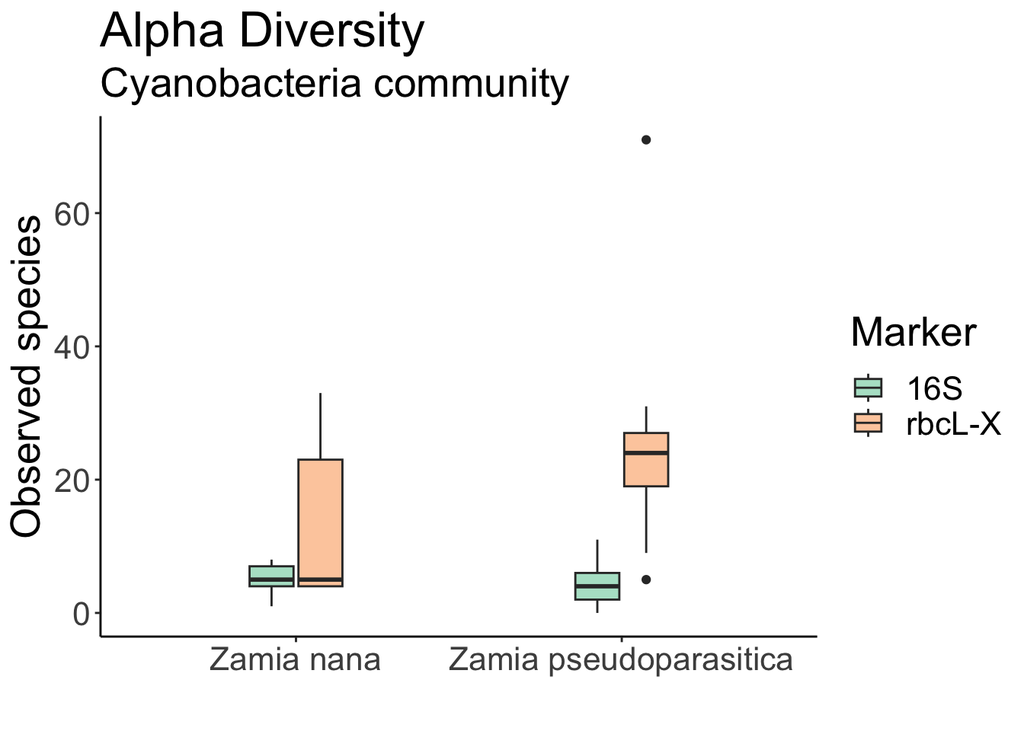

```r
cyano.div.com$Locality = factor(cyano.div.com$Locality, levels= c("El Valle, Cerro Gaital", "Donoso", "El Cope"))


Figsupp_A_cyano =
  ggplot(cyano.div.com, aes(x=Host, y=Observed, fill=Marker)) +
  ggtitle("Alpha Diversity", subtitle="Cyanobacteria community")+
  scale_fill_brewer(palette="Pastel2")+
  geom_boxplot(width = 0.3)+
  #scale_fill_grey()+
  theme_classic()+
  theme(text = element_text(size=20))+
  labs(x=" ", y = "Observed species")

Figsupp_A_cyano
```

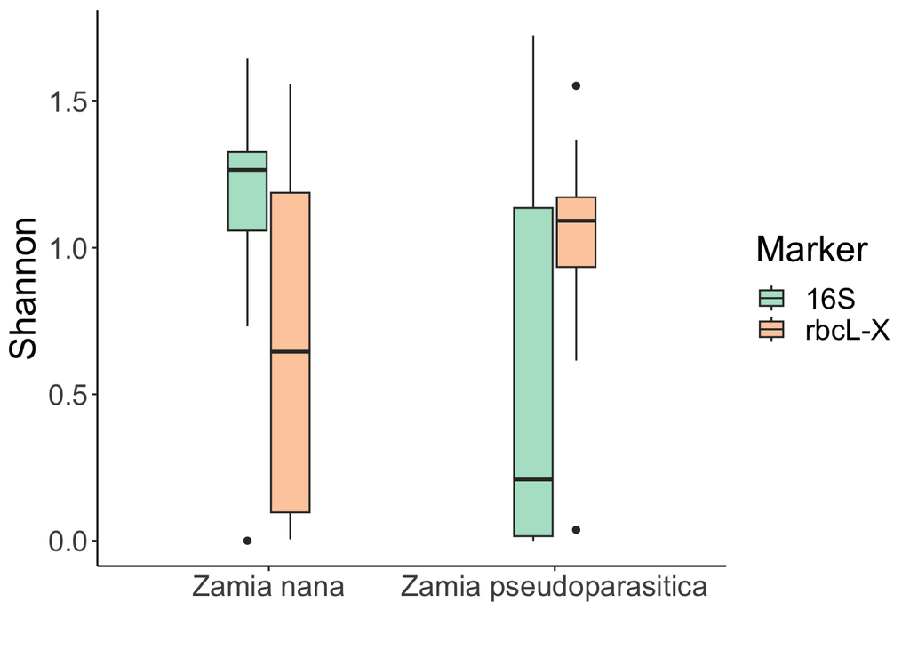

```r
Figsupp_B_cyano =
  ggplot(cyano.div.com, aes(x=Host, y=Shannon, fill=Marker)) +
  #ggtitle("Alpha Diversity", subtitle="Complete bacterial community")+
  scale_fill_brewer(palette="Pastel2")+
  geom_boxplot(width = 0.3)+
  #scale_fill_grey()+
  theme_classic()+ theme(text = element_text(size=20))+
  labs(x=" ", y = "Shannon")

Figsupp_B_cyano
```

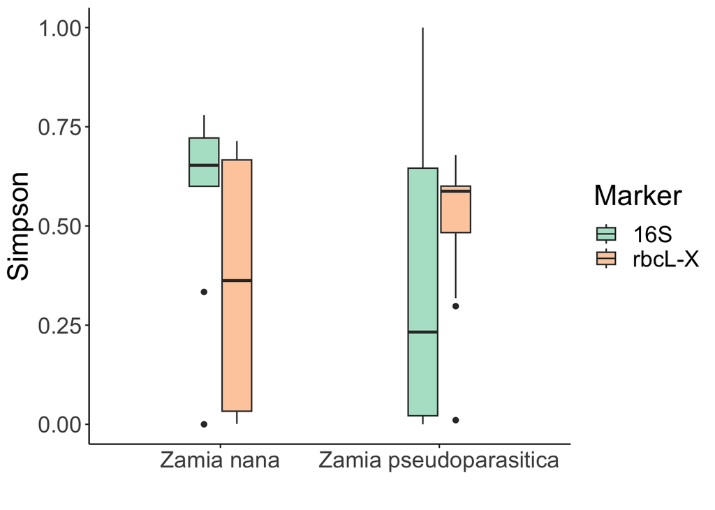

```r
Figsupp_C_cyano =
  ggplot(cyano.div.com, aes(x=Host, y=Simpson, fill=Marker)) +
  #ggtitle("Alpha Diversity", subtitle="Complete bacterial community")+
  scale_fill_brewer(palette="Pastel2")+
  geom_boxplot(width = 0.3)+
  #scale_fill_grey()+
  theme_classic()+ theme(text = element_text(size=20))+
  labs(x=" ", y = "Simpson")

Figsupp_C_cyano
```

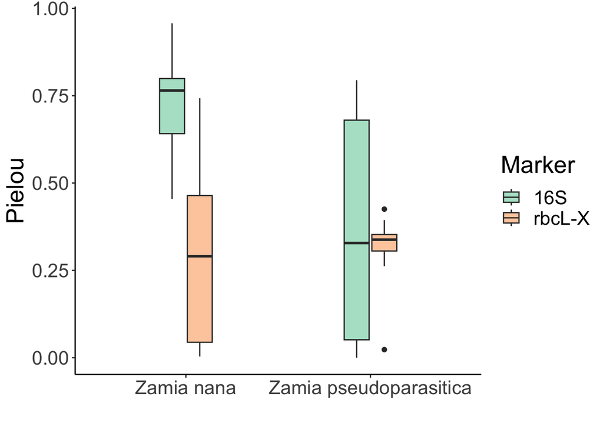

```r
Figsupp_D_cyano =
  ggplot(cyano.div.com, aes(x=Host, y=Pielou, fill=Marker)) +
  #ggtitle("Alpha Diversity", subtitle="Complete bacterial community")+
  scale_fill_brewer(palette="Pastel2")+
  geom_boxplot(width = 0.3)+
  #scale_fill_grey()+
  theme_classic()+ theme(text = element_text(size=20))+
  labs(x=" ", y = "Pielou")

Figsupp_D_cyano
```